# Insights into Cardiovascular Health: Exploring Key Indicators

Author

Hei Yee Lau (Hayley) & Jimmy Bui

Published

December 17, 2023

**Abstract**

Due to their annual high death count, cardiovascular diseases (CVDs) are a serious global health concern. These conditions frequently are unrecognized until they result in life-threatening issues like heart disease or stroke. They affect a large number of people under 70, particularly in developing nations with limited access to healthcare.

This study uses patient data to predict the likelihood of cardiac issues using predictive modeling. We utilized Kaggle data containing information on 70,000 patients, including age, blood pressure, cholesterol, and lifestyle choices. To identify patterns and learn from this data, we employed a variety of statistical method.

Our goal is to develop a predictive model that can help determine which variable are most crucial in forecasting the risk of heart disease. By taking this approach, we seek to improve doctor knowledge of the risks and discover different strategies for preventing cardiac issues.

**Introduction**

Cardiovascular diseases (CVDs) are the leading cause of mortality and disability globally, posing a serious global health concern. Despite the accessibility and effectiveness of treatment, cardiovascular disease remains a major risk factor for CVD-related mortality, leading to nearly 10 million deaths each year. Cardiovascular disease, known as the “silent killer,” typically goes undetected due to the absence of systems, leading to serious problems such as heart disease, stroke, and kidney failure if left untreated. Premature deaths due to undetected CVDs are common for people under the age of 70, especially in low and middle-income countries, this can probably be due to different advancements in the healthcare system and availability of services. In regard to this problem, our report uses machine learning approaches to forecast cardiovascular disease risk using patient clinical data. Our method is to apply supervised classification models using the Kaggle Cardiovascular Disease dataset, which contains 70,000 patient records containing 11 clinical characteristics such as demographic information, blood pressure, cholesterol, glucose levels, and lifestyle factors. To find the model with the greatest accuracy, we split the dataset into training and test sets, training multiple models such as logistic regression, random forests, and binomial logit, and using k-fold validation. We help to construct a prediction model capable of assessing components based on their significance in forecasting heart disease risk by finding important risk factors and influential predictors using these models.

Literature: https://www.cdc.gov/globalhealth/healthprotection/ncd/cardiovascular-diseases.html

**Data Description**

The Cardiovascular Disease dataset is sourced from the medical examination database, collected at the time of patients’ medical evaluations. The data is intended to aid in predicting the presence or absence of cardiovascular disease based on various health-related features. While the exact origin of the dataset is not specified, t is commonly in cardiovascular disease research.

Variable:

**Goal**

The objectives of this research are to give useful insights into primary risk factors linked to cardiovascular disease, providing healthcare practitioners with useful data for tailored risk assessment and proactive treatments. Second, by using the patient data into a prediction model, this model intends to improve cardiovascular outcomes on a larger scale, and perhaps develop or change preventative care approaches.

**Statistical Method**

In this project, we would use several models to predict cardiovascular disease and evaluate their performance by having different tests.

The first model we built is the **Binary Logit Response Modeling**. The binary logit response model, commonly known as logistic regression, is a statistical method for modeling a binary outcome’s probability. We have applied logistic regression to predict the probability of cardiovascular disease presence (“cardio”) based on various features. The logistic function is used to model the relationship between the predictor variables and the log-odd of the binary outcome. The model’s coefficients are estimated through maximum likelihood estimation. It is a standard method for binary classification with interpretable coefficients.

Moreover, we have built a **Binary Tree**. A binary tree is a decision tree with binary splits at each node. In our analysis, a binary tree has been employed for classification purposes. The tree structure is formed by recursively partitioning the dataset based on the predictor variables. At each node, the algorithm selects the variable and splits the point that optimally decides the data into subsets. This process is repeated until a stopping criterion is met. Binary trees are interpretable and can capture complex relationships in the data. They can capture non-linear relationships and are easy to understand. However, a single tree might not capture complex interactions. Therefore, we will also have the following models. We have implemented the CART algorithm using the R package rpart to grow the tree using all features. We calculated the CP value, found the smaller xerror value, and the root node error that the formula shows below.

$$\text{Root Node Error} = \frac{\text{No. of 1's in the training dataset}}{\text{Size of the training dataset}}$$

We have also built a **Random Forest**, which is an ensemble learning method that builds multiple decision trees and merges their predictions to improve accuracy and control overfitting. It creates a “forest” of trees by training each tree on a random subset of the data and a random subset of the features. The final prediction is typically obtained through a majority vote or averaging. Random Forest is known for its robustness and ability to handle complex relationships in the data. It can address the limitations of a single decision tree, providing robustness and improved accuracy. We used the R package ranger to implement the random forest algorithm, with the Gini index as the impurity measure for classification. Since we would like to understand which variables have the most predictive power, we use the vi() function in the R package vip to extract and print a table of variable importance scores. Variables with high importance will have a significant impact on the binary outcomes, we can consider dropping variables with low importance from the model and leading to a more parsimonious model.

Finally, we have the **Gradient Boosting** model. It is another ensemble method that builds a series of weak learners, such as decision trees, sequentially. Each tree corrects the errors of the previous one, with a higher weight given to the misclassified observations. Gradient Boosting aims to minimize a loss function by iteratively optimizing the model. It often provides superior predictive performance but requires careful tuning to avoid overfitting. It is a powerful algorithm that builds on the strengths of decision trees, often achieving high predictive performance.

```r
library(readr)

data <- read.csv("cardio_train.csv",header = TRUE, sep = ";")
```

```r
head(data)
```

```
  id   age gender height weight ap_hi ap_lo cholesterol gluc smoke alco active
1  0 18393      2    168     62   110    80           1    1     0    0      1
2  1 20228      1    156     85   140    90           3    1     0    0      1
3  2 18857      1    165     64   130    70           3    1     0    0      0
4  3 17623      2    169     82   150   100           1    1     0    0      1
5  4 17474      1    156     56   100    60           1    1     0    0      0
6  8 21914      1    151     67   120    80           2    2     0    0      0
  cardio
1      0
2      1
3      1
4      1
5      0
6      0
```

```r
# Assuming 'age', 'height', 'weight', 'ap_hi', and 'ap_lo' are continuous variables
data$cardio<- as.factor(ifelse(data$cardio==1,1,0))
data$age_in_years <- as.integer(floor(data$age / 365))
#data[, c('height', 'weight', 'ap_hi', 'ap_lo')] <- scale(data[, c('age', 'height', 'weight', 'ap_hi', 'ap_lo')])
data$female<-as.integer(ifelse(data$gender==1,1,0))
#data$male<-as.integer(ifelse(data$gender==2,1,0))
data$weight<-as.integer(data$weight)
data$gender<-NULL
data$age<-NULL

head(data)
```

```
  id height weight ap_hi ap_lo cholesterol gluc smoke alco active cardio
1  0    168     62   110    80           1    1     0    0      1      0
2  1    156     85   140    90           3    1     0    0      1      1
3  2    165     64   130    70           3    1     0    0      0      1
4  3    169     82   150   100           1    1     0    0      1      1
5  4    156     56   100    60           1    1     0    0      0      0
6  8    151     67   120    80           2    2     0    0      0      0
  age_in_years female
1           50      0
2           55      1
3           51      1
4           48      0
5           47      1
6           60      1
```

```r
str(data)
```

```
'data.frame':   70000 obs. of  13 variables:
 $ id          : int  0 1 2 3 4 8 9 12 13 14 ...
 $ height      : int  168 156 165 169 156 151 157 178 158 164 ...
 $ weight      : int  62 85 64 82 56 67 93 95 71 68 ...
 $ ap_hi       : int  110 140 130 150 100 120 130 130 110 110 ...
 $ ap_lo       : int  80 90 70 100 60 80 80 90 70 60 ...
 $ cholesterol : int  1 3 3 1 1 2 3 3 1 1 ...
 $ gluc        : int  1 1 1 1 1 2 1 3 1 1 ...
 $ smoke       : int  0 0 0 0 0 0 0 0 0 0 ...
 $ alco        : int  0 0 0 0 0 0 0 0 0 0 ...
 $ active      : int  1 1 0 1 0 0 1 1 1 0 ...
 $ cardio      : Factor w/ 2 levels "0","1": 1 2 2 2 1 1 1 2 1 1 ...
 $ age_in_years: int  50 55 51 48 47 60 60 61 48 54 ...
 $ female      : int  0 1 1 0 1 1 1 0 1 1 ...
```

```r
table(data$cardio)
```

```
    0     1
35021 34979
```

```r
# Check for missing values in the entire data frame
missing_values <- is.na(data)

# Count missing values in each column
missing_counts <- colSums(missing_values)

# Display columns with missing values
columns_with_missing <- names(missing_counts[missing_counts > 0])
columns_with_missing
```

```
character(0)
```

There is no missing value in the data set.

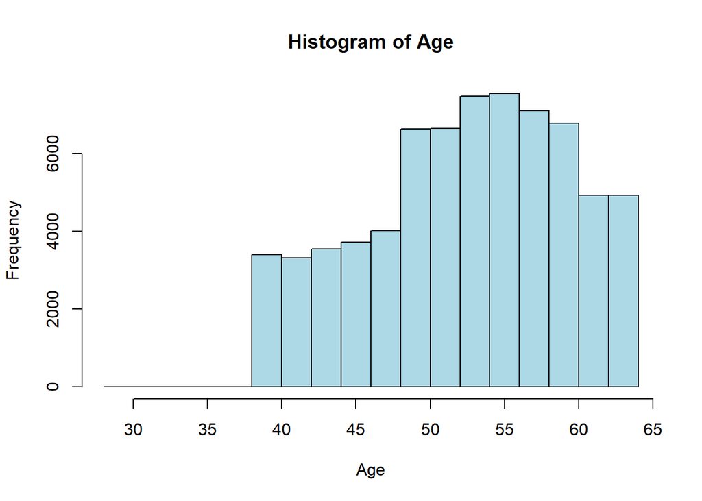

```r
#Histogram of Age Variable
hist(data$age, main = "Histogram of Age", xlab = "Age", col = "lightblue", border = "black")
```

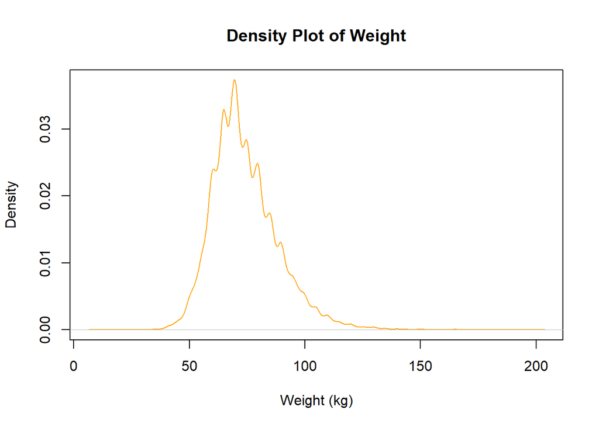

```r
# Density Plot for weight variable
plot(density(data$weight), main = "Density Plot of Weight", xlab = "Weight (kg)", col = "orange")
```

The distribution of weight in kilograms among the patients indicated that most patients weigh around 65-75 kg.

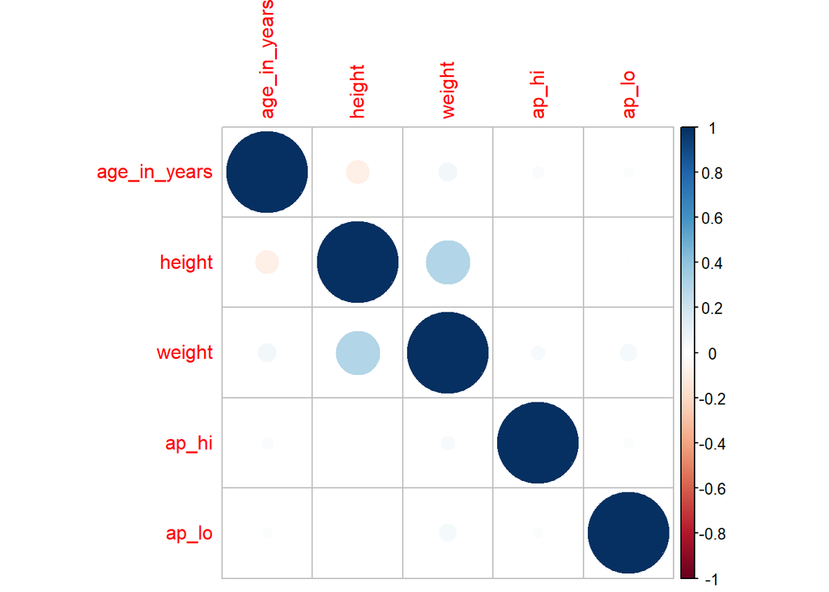

```r
#Correlation Heatmap
library(corrplot)
cor_matrix <- cor(data[, c("age_in_years", "height", "weight", "ap_hi", "ap_lo")])
corrplot(cor_matrix, method = "circle")
```

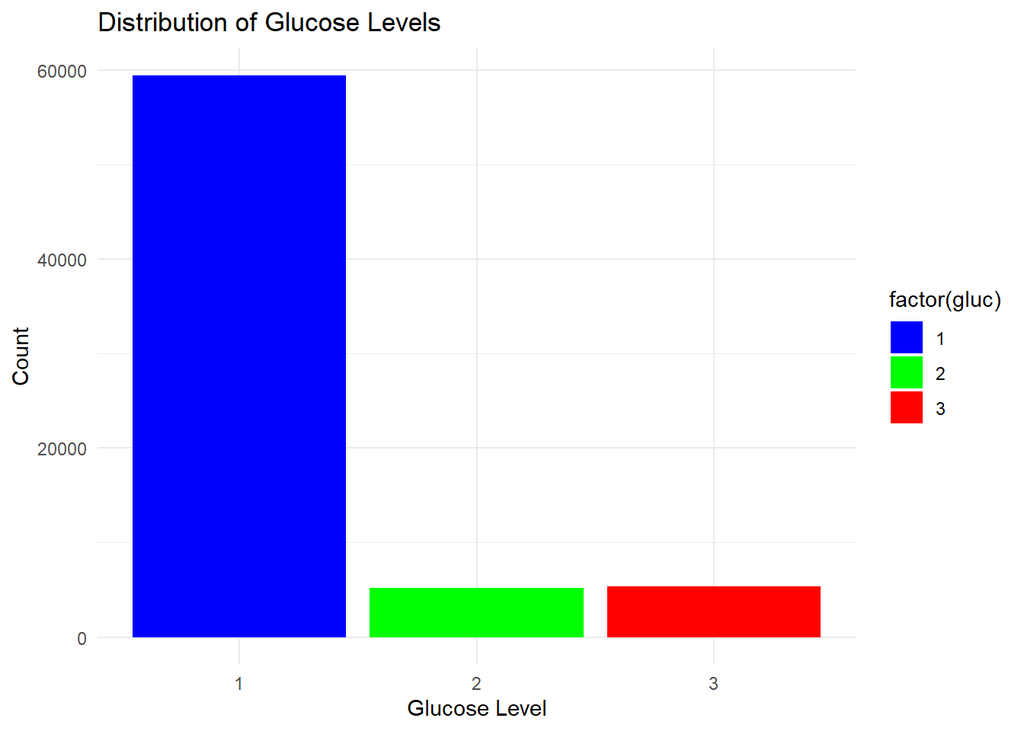

```r
library(ggplot2)

ggplot(data, aes(x = factor(gluc), fill = factor(gluc))) +
  geom_bar() +
  labs(title = "Distribution of Glucose Levels",
       x = "Glucose Level",
       y = "Count") +
  scale_fill_manual(values = c("1" = "blue", "2" = "green", "3" = "red")) +
  theme_minimal()
```

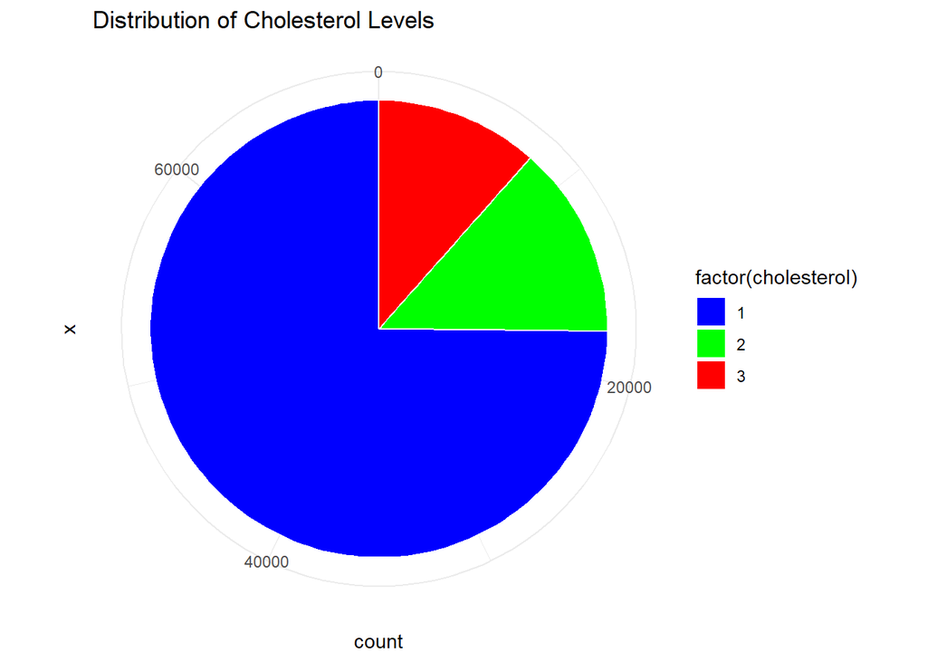

```r
ggplot(data, aes(x = "", fill = factor(cholesterol))) +
  geom_bar(width = 1, color = "white") +
  coord_polar("y") +
  labs(title = "Distribution of Cholesterol Levels") +
  scale_fill_manual(values = c("1" = "blue", "2" = "green", "3" = "red")) +
  theme_minimal()
```

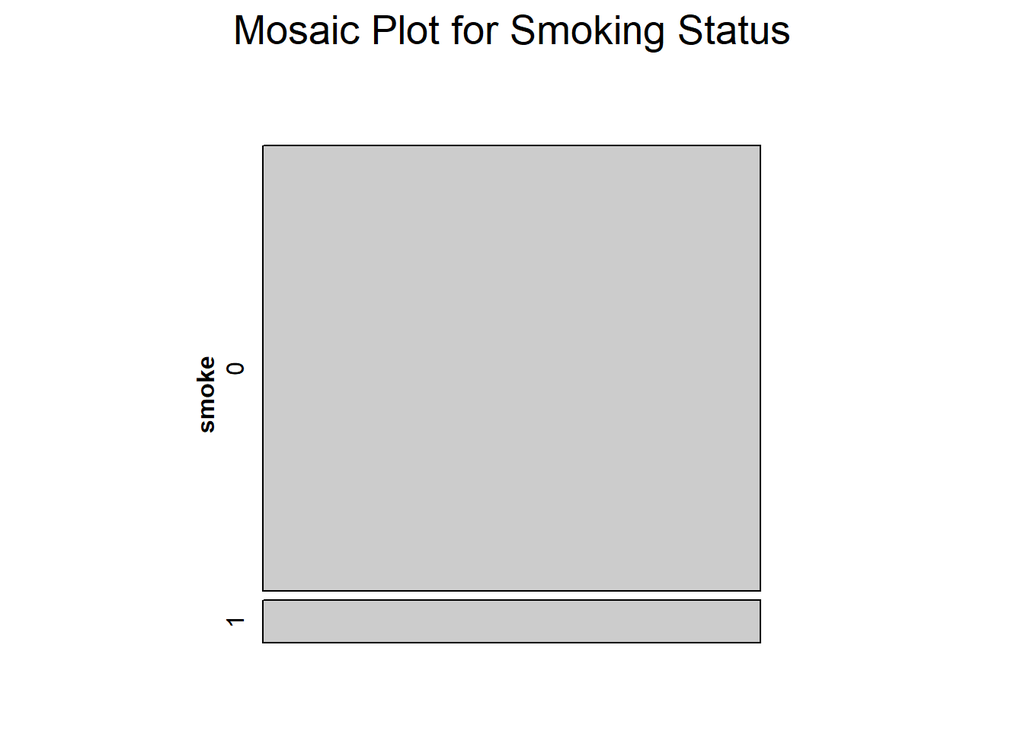

```r
library(vcd)
# Assuming your data frame is named 'data', adjust if needed
# Mosaic plot for Smoke
mosaic(~ smoke, data = data, main = "Mosaic Plot for Smoking Status")
```

Majority of the patients in our data set do not smoke.

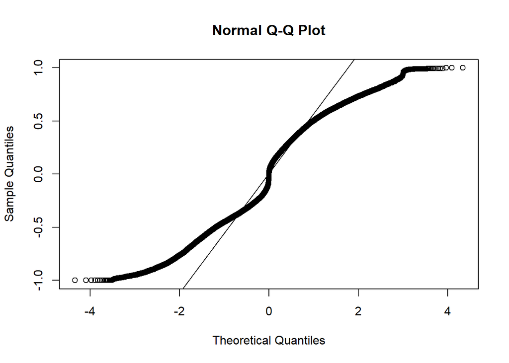

```r
#check the normality of residuals ?? Do we need??
# Fit the logistic regression model
model <- glm(cardio ~ height+weight +ap_hi+ap_lo+ cholesterol+gluc+age_in_years+female+smoke+alco+active, data = data, family = binomial(link = "logit"))
# Residuals
residuals <- residuals(model, type = "response")

# Diagnostic plot for normality of residuals
qqnorm(residuals)
qqline(residuals)
```

The Normal Q-Q plot help us visually check the normality of the residuals. It appears that the residuals are not perfectly normal as the point deviate from the straight line, especially at both ends. There are plotted points forming a curve that deviates from the qqline. The curve formed by the plotted points suggests a departure from linearity.

```r
library(goftest)
library(ResourceSelection)
```

```
ResourceSelection 0.3-6      2023-06-27
```

```r
ad.test(residuals)
```

```
    Anderson-Darling test of goodness-of-fit
    Null hypothesis: uniform distribution
    Parameters assumed to be fixed

data:  residuals
An = Inf, p-value = 8.571e-09
```

The Anderson-Darling test of goodness-of-fit tests whether the residuals from the logistic regression model follow a uniform distribution. The null hypothesis $H_0$ is that the residuals are uniformly distributed(indicating normality)

Given the very small p-value of 8.571e-09, we have evidence to suggest that the residuals do not follow a uniform distribution. This could be an indication that the normality assumption of residual might be violated.

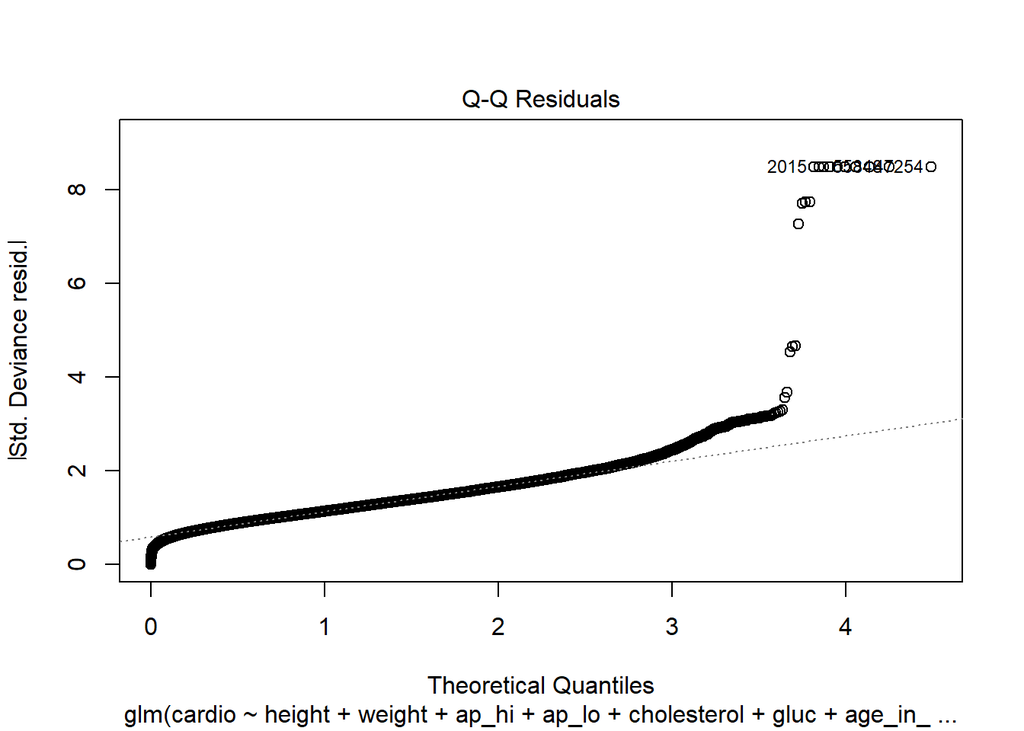

```r
#check the linearity
plot(model, which = 2)
```

We can also check the linearity assumption in a logistic regression model. The second diagnostic plot in logistic regression is typically used to assess the linearity assumption. We can see that there is a clear pattern shown in the above graph and a lot of outliers cluster in the upper right, which we might suggest the assumption of linearity might not hold.

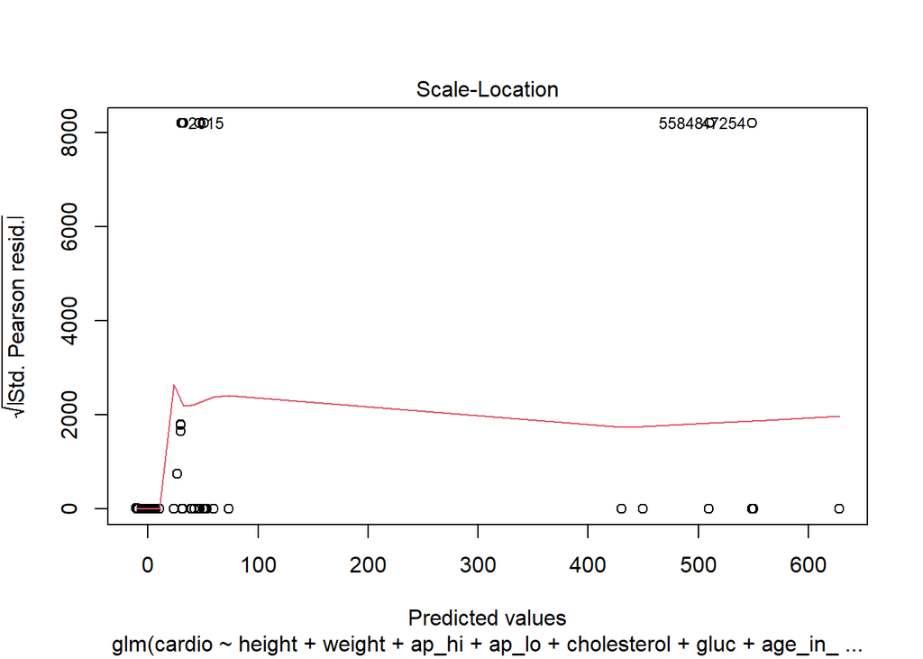

```r
#Homoscedasticity of Residuals
plot(model, which = 3)
```

The x-axis represents the fitted (predicted) values from the logit model. The y-axis represents the square root o the standardized residuals. We can see that most of the data point cluster in the left down corner and some of them are on the upper left and upper right. The data point is not consistent spread across the range of fitted values, which might suggests it is violate the Homoscedasticity assumption.

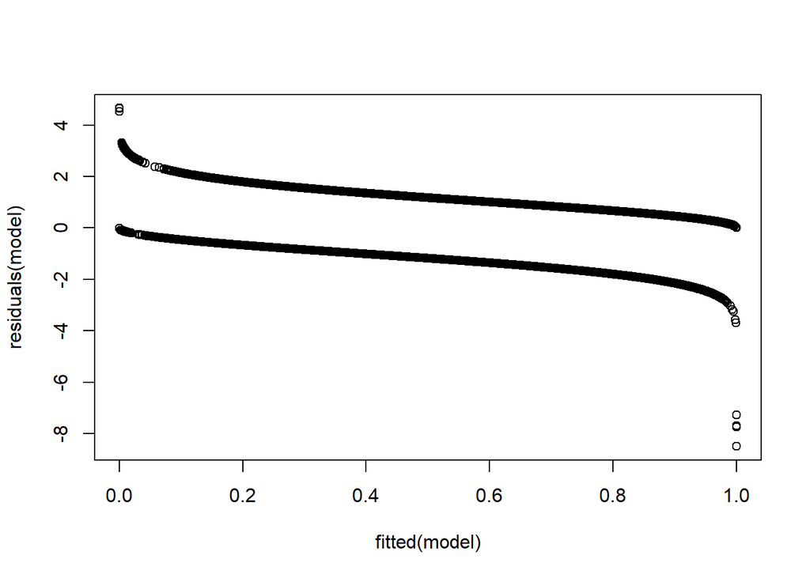

```r
#Independence of Observation
plot(residuals(model) ~ fitted(model))
```

```r
car::durbinWatsonTest(model)
```

```
 lag Autocorrelation D-W Statistic p-value
   1     0.009302883      1.981368   0.018
 Alternative hypothesis: rho != 0
```

The independence of observations assumptions in logistic regression assumes that the observations are independent of each other. Each observation in the data set should be independent of the others.

In the scatterplot of residuals against fitted values, we can see that the residuals is not randomly scattered around zero and we can see the pattern and trend that it is sightly decreasing, therefore, it might suggests a violation of the independence assumption.

The Durbin-Watson (D-W) statistic tests for autocorrelation in the residuals of a regression model. The test statistic ranges from 0 to 4, with values close to 2 indicating no autocorrelation (independence of residuals). The critical values for the test depend on the sample size and the desired level of significance.

In summary, the result suggest that there might be some evidence of autocorrelation in the residuals at lag 1 and violation of the assumption of independence of observations.

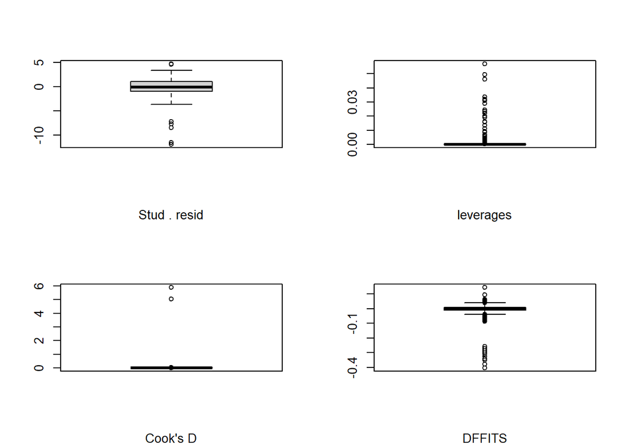

```r
#Find Outliers
par(mfrow=c(2,2))
boxplot (rstudent (model), sub =" Stud . resid ")
boxplot (influence(model)$hat , sub=" leverages ")
boxplot(cooks.distance(model), sub = "Cook's D")
boxplot(dffits(model), sub = "DFFITS")
```

```r
# Extract residuals, hat values, Cook's D, and DFFITS
residuals <- rstudent(model)
hat_values <- influence(model)$hat
cooks_d <- cooks.distance(model)
dffits_values <- dffits(model)
```

```r
# Set threshold values for identification of outliers
residual_threshold <- 2  # Example threshold for residuals
hat_threshold <- 0.05  # Example threshold for hat values
cooks_d_threshold <- 4 / nrow(model)  # Example threshold for Cook's D
dffits_threshold <- 2 * sqrt(ncol(data.frame(model.matrix(model)))) / nrow(model)  # Example threshold for DFFITS

# Identify outliers based on thresholds
residual_outliers <- which(abs(residuals) > residual_threshold)
hat_outliers <- which(hat_values > hat_threshold)
cooks_d_outliers <- which(cooks_d > cooks_d_threshold)
dffits_outliers <- which(abs(dffits_values) > dffits_threshold)

# Combine all outlier indices
all_outliers <- unique(c(residual_outliers, hat_outliers, cooks_d_outliers, dffits_outliers))

# Print the indices of potential outliers
#cat("Potential outliers:", all_outliers, "\n")
# Remove outliers
clean_data <- data[-all_outliers, ]

# Check the dimensions of the cleaned data
dim(clean_data)
```

```
[1] 69238    13
```

We have set the threshold for identifying outliers based on the absolute value of residuals, Hat values (leverages), Cook’s D statistic and DFFITS values. Then, we have identify the outliers by different methods and combining outliers indices that obtained from the different methods. We can see that the observation is decrease from 70000 to 69238 rows after remove the outliers.

```r
clean_model <- glm(cardio ~ height + weight + ap_hi + ap_lo + cholesterol + gluc +smoke+alco+ age_in_years + female+active, data = clean_data, family = binomial(link = "logit"))
summary(clean_model)
```

```
Call:
glm(formula = cardio ~ height + weight + ap_hi + ap_lo + cholesterol +
    gluc + smoke + alco + age_in_years + female + active, family = binomial(link = "logit"),
    data = clean_data)

Coefficients:
               Estimate Std. Error z value Pr(>|z|)
(Intercept)  -1.237e+01  2.528e-01 -48.942  < 2e-16 ***
height       -4.755e-03  1.315e-03  -3.617 0.000298 ***
weight        1.347e-02  7.095e-04  18.986  < 2e-16 ***
ap_hi         7.001e-02  7.672e-04  91.254  < 2e-16 ***
ap_lo         3.313e-04  9.128e-05   3.630 0.000283 ***
cholesterol   5.968e-01  1.639e-02  36.423  < 2e-16 ***
gluc         -1.512e-01  1.838e-02  -8.225  < 2e-16 ***
smoke        -1.848e-01  3.573e-02  -5.171 2.32e-07 ***
alco         -2.138e-01  4.353e-02  -4.911 9.08e-07 ***
age_in_years  5.577e-02  1.389e-03  40.160  < 2e-16 ***
female        1.508e-02  2.242e-02   0.673 0.501250
active       -2.576e-01  2.245e-02 -11.473  < 2e-16 ***
---
Signif. codes:  0 '***' 0.001 '**' 0.01 '*' 0.05 '.' 0.1 ' ' 1

(Dispersion parameter for binomial family taken to be 1)

    Null deviance: 95983  on 69237  degrees of freedom
Residual deviance: 73926  on 69226  degrees of freedom
AIC: 73950

Number of Fisher Scoring iterations: 6
```

From the above result, for each additional year in age, the log-odds of having cardiovascular disease increase by 0.05577, assuming other factors are constant. With each additional unit increase in weight, the log-odds of having cardiovascular disease increase by 0.01347. A one-unit increase in systolic blood pressure (ap_hi) is associated with a 0.07001 increase in the log-odds of having cardiovascular disease. Individuals with higher cholesterol levels have higher log-odds of having cardiovascular disease. Specifically, for a one-unit increase in cholesterol, the log-odds increase by 0.5968. Conversely, for a one-unit increase in glucose (gluc), the log-odds of having cardiovascular disease decrease by 0.1512. Smoking (smoke) is associated with a decrease in the log-odds of cardiovascular disease. The log-odds decrease by 0.1848 for smokers compared to non-smokers. Alcohol consumption (alco) is associated with a decrease in the log-odds of cardiovascular disease. The log-odds decrease by 0.2138 for individuals who consume alcohol compared to non-drinkers. Being physically active (active) is associated with a decrease in the log-odds of cardiovascular disease. The log-odds decrease by 0.2576 for physically active individuals compared to inactive individuals.

The null deviance is 95983 on 69237 degrees of freedom and the residual deviance is 73926 on 69226 degrees of freedom

```r
# Set a seed for reproducibility
set.seed(1235678)

train.prop <- 0.90
strats <- clean_data$cardio
rr <- split(1:length(strats), strats)
idx <- sort(as.numeric(unlist(sapply(rr,
        function(x) sample(x, length(x) * train.prop))))
)
data.train <- clean_data[idx,]
data.test <- clean_data[-idx,]
```

```r
#For cross-validation data
set.seed(1235678)

# Proportion of data to use for cross-validation (e.g., 10%)
cross_val_prop <- 0.10

# Determine the number of rows for cross-validation
cross_val_size <- ceiling(nrow(data.train) * cross_val_prop)

# Randomly select rows for cross-validation
cross_val_indices <- sample(1:nrow(data.train), cross_val_size)

# Create the cross-validation dataset
data.cross <- data.train[cross_val_indices, ]

# Update the training dataset by removing the cross-validation rows
data.train.1 <- data.train[-cross_val_indices, ]
```

```r
# Remove rows with missing values in the training set
data.train.1 <- na.omit(data.train.1)

# Remove rows with missing values in the test set
data.test <- na.omit(data.test)

# Remove rows with missing values in the cross-validation set
data.cross <- na.omit(data.cross)
```

In the above code, we have divided the dataset into three parts, which are training data, testing data and cross-validation data. Then, we have check if there is NA value in the dataset and remove them all.

#standardize the training, test and cross-validation sets

```r
library(caret)
contpredcols <- c(2:7, 12)
# Find the mean and std dev of data.train
normParam <- preProcess(data.train.1[, contpredcols], method = c("center", "scale"))
#standardize
train.set<-cbind(data.train.1[,c("cardio", "smoke", "active", "alco", "female")], predict(normParam, data.train.1[,contpredcols]))

test.set<-cbind(data.test[,c("cardio", "smoke", "active", "alco", "female")], predict(normParam, data.test[,contpredcols]))
cross.set<- cbind(data.cross[,c("cardio", "smoke", "active", "alco", "female")], predict(normParam, data.cross[,contpredcols]))
```

```r
sum(is.na(train.set))
```

```
[1] 0
```

```r
sum(is.na(test.set))
```

```
[1] 0
```

```r
sum(is.na(cross.set))
```

```
[1] 0
```

```r
summary(train.set$cardio)/nrow(train.set)
```

```
        0         1
0.4980475 0.5019525
```

```r
summary(cross.set$cardio)/nrow(cross.set)
```

```
        0         1
0.4947047 0.5052953
```

```r
summary(test.set$cardio)/nrow(test.set)
```

```
        0         1
0.4977617 0.5022383
```

```r
#need to drop the variable cardio, but in the last step.
```

```r
full.logit<-glm(cardio~smoke+active+alco+female+height+weight+ap_hi+ap_lo+cholesterol+gluc+age_in_years , data=train.set, family=binomial(link="logit"))
summary(full.logit)
```

```
Call:
glm(formula = cardio ~ smoke + active + alco + female + height +
    weight + ap_hi + ap_lo + cholesterol + gluc + age_in_years,
    family = binomial(link = "logit"), data = train.set)

Coefficients:
             Estimate Std. Error z value Pr(>|z|)
(Intercept)   0.37617    0.02849  13.205  < 2e-16 ***
smoke        -0.19359    0.03971  -4.876 1.09e-06 ***
active       -0.24030    0.02497  -9.623  < 2e-16 ***
alco         -0.20662    0.04846  -4.264 2.01e-05 ***
female        0.01881    0.02490   0.755  0.45002
height       -0.03617    0.01196  -3.024  0.00249 **
weight        0.18196    0.01126  16.157  < 2e-16 ***
ap_hi         7.95261    0.09630  82.579  < 2e-16 ***
ap_lo         0.05364    0.01647   3.257  0.00113 **
cholesterol   0.40226    0.01227  32.793  < 2e-16 ***
gluc         -0.07949    0.01162  -6.842 7.79e-12 ***
age_in_years  0.38054    0.01044  36.435  < 2e-16 ***
---
Signif. codes:  0 '***' 0.001 '**' 0.01 '*' 0.05 '.' 0.1 ' ' 1

(Dispersion parameter for binomial family taken to be 1)

    Null deviance: 77744  on 56080  degrees of freedom
Residual deviance: 59827  on 56069  degrees of freedom
AIC: 59851

Number of Fisher Scoring iterations: 6
```

Estimated coefficient for active is -0.24030 with a SE of 0.02497, For each unit increase in the ‘active’ variable, the log odds of having cardiovascular disease decrease by 0.24030 This suggests that being more physically active is associated with lower log odds of having cardiovascular disease.

Estimated coefficient for alco is -0.20662 with SE of 0.04846, A one-unit increase in the “alco” variable is associated with a decrease of 0.20662 in the log-odds of having cardio.

Estimated coefficient for female is 0.01881. It means a one-unit increase in the “female” variable (assuming it’s binary) is associated with an increase of 0.01881 in the log-odds of having cardio.

Estimated coefficient for height is -0.03617 with SE of 0.01196, A one-unit increase in the “height” variable is associated with a decrease of 0.03617 in the log-odds of having cardio.

Estimated coefficient for weight is 0.18196 with SE of 0.01126, A one-unit increase in the “weight” variable is associated with an increase of 0.18196 in the log-odds of having cardio. This implies that higher weight is associated with higher log odds of having cardiovascular disease

Estimated coefficient for cholesterol is 0.40226 with SE of 0.01227, A one-unit increase in the “cholesterol” variable is associated with an increase of 0.40226 in the log-odds of having cardio.

Estimated coefficient for ap_hi is 7.95261 with SE of 0.09630, increase in expected log count for one unit increase in ap_hi is 7.95261

Estimated coefficient for ap_lo is 0.05364 with SE of 0.01647, increase in expected log count for one unit increase in ap_lo is 0.05364

Estimated coefficient for gluc is -0.07949 with SE of 0.01162. A one-unit increase in the “gluc” variable is associated with a decrease of 0.07949 in the log-odds of having cardio.

Estimated coefficient for age_in_years is 0.38054 with SE of 0.01044, A one-unit increase in the “age_in_years” variable is associated with an increase of 0.38054 in the log-odds of having cardio. This suggests that older individuals are expected to have higher log odds of having cardiovascular disease.

The null deviance is 77744 on 56080 degrees of freedom and the residual deviance: 59827 on 56069 degrees of freedom. AIC is 59851.

```r
(correlation_matrix<- cor(data[sapply(data, is.numeric)]))
```

```
                       id       height       weight         ap_hi        ap_lo
id            1.000000000 -0.003037818 -0.001833975  3.355599e-03 -0.002529280
height       -0.003037818  1.000000000  0.291001242  5.487764e-03  0.006150467
weight       -0.001833975  0.291001242  1.000000000  3.070158e-02  0.043703078
ap_hi         0.003355599  0.005487764  0.030701580  1.000000e+00  0.016085513
ap_lo        -0.002529280  0.006150467  0.043703078  1.608551e-02  1.000000000
cholesterol   0.006106200 -0.050225952  0.141755039  2.377792e-02  0.024019290
gluc          0.002466780 -0.018594670  0.106863754  1.184068e-02  0.010805666
smoke        -0.003699162  0.187989399  0.067751883 -9.220248e-04  0.005186130
alco          0.001209946  0.094418693  0.067076840  1.408333e-03  0.010601240
active        0.003755116 -0.006569547 -0.016864280 -3.300248e-05  0.004780258
age_in_years  0.003813769 -0.081506092  0.053567179  2.085430e-02  0.017619570
female       -0.003502185 -0.499033428 -0.155416041 -6.005309e-03 -0.015253971
              cholesterol         gluc         smoke         alco        active
id            0.006106200  0.002466780 -0.0036991623  0.001209946  3.755116e-03
height       -0.050225952 -0.018594670  0.1879893994  0.094418693 -6.569547e-03
weight        0.141755039  0.106863754  0.0677518834  0.067076840 -1.686428e-02
ap_hi         0.023777922  0.011840678 -0.0009220248  0.001408333 -3.300248e-05
ap_lo         0.024019290  0.010805666  0.0051861304  0.010601240  4.780258e-03
cholesterol   1.000000000  0.451577524  0.0103544151  0.035760386  9.911297e-03
gluc          0.451577524  1.000000000 -0.0047564831  0.011245771 -6.769518e-03
smoke         0.010354415 -0.004756483  1.0000000000  0.340093768  2.585797e-02
alco          0.035760386  0.011245771  0.3400937679  1.000000000  2.547583e-02
active        0.009911297 -0.006769518  0.0258579688  0.025475829  1.000000e+00
age_in_years  0.154012434  0.098388213 -0.0476485189 -0.029756330 -9.998445e-03
female        0.035821413  0.020491035 -0.3381351364 -0.170966429 -5.865669e-03
             age_in_years       female
id            0.003813769 -0.003502185
height       -0.081506092 -0.499033428
weight        0.053567179 -0.155416041
ap_hi         0.020854301 -0.006005309
ap_lo         0.017619570 -0.015253971
cholesterol   0.154012434  0.035821413
gluc          0.098388213  0.020491035
smoke        -0.047648519 -0.338135136
alco         -0.029756330 -0.170966429
active       -0.009998445 -0.005865669
age_in_years  1.000000000  0.022913176
female        0.022913176  1.000000000
```

#Check the correlation

```r
pred.df <- train.set[,-1]
cor.pred <- cor(pred.df)
off.diag <- function(x) x[col(x) > row(x)]
v <- off.diag(cor.pred) # simple correlations
table(v >=0.95)
```

```
FALSE
   55
```

```r
table(v >=0.99)
```

```
FALSE
   55
```

There is no correlation between all the predictors that have a correlation coefficient greater than or equal to 0.99, 0.95.

```r
# partial correlation
library(ppcor)
pcor1 <- pcor(pred.df)
vp <- off.diag(pcor1$estimate)
table(vp >= 0.5)
```

```
FALSE
   55
```

Partial correlations provide a measure of the strength and direction of a linear relationship between two variables while controlling for the influence of other variables.

There is no pairs of variables have a partial correlation coefficient greater than or equal to 0.5.

```r
library(car)
car::vif(full.logit)
```

```
       smoke       active         alco       female       height       weight
    1.240367     1.002995     1.136571     1.426070     1.421012     1.146432
       ap_hi        ap_lo  cholesterol         gluc age_in_years
    1.056191     1.019883     1.286845     1.280286     1.016402
```

A VIF of 1 indicates no correlation between the predictor and the other predictors. Generally, a VIF value above 5 or 10 indicates a problematic amount of collinearity. None of the VIF values are particularly high. Therefore, based on the VIF values, there does not seem to be a problematic level of multicollinearity among the predictor variables in the logit model.

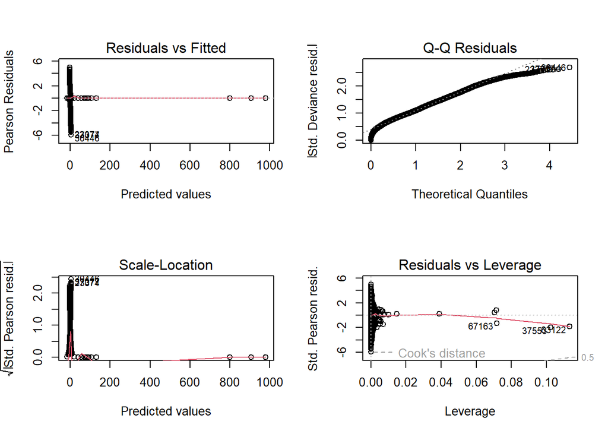

```r
#residual check
par(mfrow=c(2,2))
plot(full.logit)
```

```r
with(full.logit, cbind(deviance, df=df.residual, p=pchisq(deviance, df.residual, lower.tail=FALSE)))
```

```
     deviance    df            p
[1,] 59826.57 56069 2.341136e-28
```

The deviance of 59826.57 suggests that the model does not fit the data perfectly, as there is some lack of fit. With 56069 degrees of freedom, this is likely associated with a chi-squared test. The very low p-value indicates that the deviance is statistically significant. In other words, it suggests that the model is significant different from a perfect fit.

```r
null.logit<-glm(cardio~1, data=data.train.1, family = binomial(link="logit"))
summary(null.logit)
```

```
Call:
glm(formula = cardio ~ 1, family = binomial(link = "logit"),
    data = data.train.1)

Coefficients:
            Estimate Std. Error z value Pr(>|z|)
(Intercept) 0.007810   0.008446   0.925    0.355

(Dispersion parameter for binomial family taken to be 1)

    Null deviance: 77744  on 56080  degrees of freedom
Residual deviance: 77744  on 56080  degrees of freedom
AIC: 77746

Number of Fisher Scoring iterations: 3
```

The above is the null model that only contain intercept. The estimate for the intercept is 0.007810, with a standard error of 0.008446. Z-value is 0.925. The null deviance and residual deviance are 77744 on 56080 degrees of freedom. AIC is 77746.

The model has only an intercept term, that it doesn’t include any predictor variables. Since the p-value is 0.355 which is higher than the significant level (0.05), indicating that the intercept is not statistically significant. The null and residual deviance are the same, suggesting that the model doesn’t provide a better fit than a model with just the intercept.

```r
#calculate the extra d.f.
with(full.logit, cbind(deviance = null.deviance-deviance,
df = df.null-df.residual,
p = pchisq(null.deviance-deviance,
df.null-df.residual,
lower.tail=FALSE)))
```

```
     deviance df p
[1,] 17917.35 11 0
```

```r
(disp.est <- full.logit$deviance/full.logit$df.residual)
```

```
[1] 1.067017
```

The deviance is a measure of how well the model fits the data, A value greater than 1 suggests that there is more variability in the response variable than the model accounts for. From the above result, a value of 1.067017 suggests some overdispersion in the model.

```r
library(caret)

# Calculate cross-validation data predictions from the full model
pred.cross<-predict(full.logit, newdata=cross.set, type='response')

# Create binary predictions from probabilities
b_cross <- ifelse(pred.cross > 0.5, 1, 0)
b_cross <- factor(b_cross, levels = levels(as.factor(data.cross$cardio)))

# Create the confusion matrix
cm.cross <- confusionMatrix(reference = as.factor(data.cross$cardio), data = as.factor(b_cross), mode = "everything")

# Display the confusion matrix
cm.cross
```

```
Confusion Matrix and Statistics

          Reference
Prediction    0    1
         0 2428 1001
         1  655 2148

               Accuracy : 0.7343
                 95% CI : (0.7231, 0.7452)
    No Information Rate : 0.5053
    P-Value [Acc > NIR] : < 2.2e-16

                  Kappa : 0.4691

 Mcnemar's Test P-Value : < 2.2e-16

            Sensitivity : 0.7875
            Specificity : 0.6821
         Pos Pred Value : 0.7081
         Neg Pred Value : 0.7663
              Precision : 0.7081
                 Recall : 0.7875
                     F1 : 0.7457
             Prevalence : 0.4947
         Detection Rate : 0.3896
   Detection Prevalence : 0.5502
      Balanced Accuracy : 0.7348

       'Positive' Class : 0
```

The proportion of correctly classified instances out of the total instances (Accuracy) is approximately 73.43%.

The ability of the model to correctly identify positive instances (sensitivity) is 78.75%.

The ability of the model to correctly identify negative instances (specificity) is 68.21%.

```r
library(caret)

# Calculate test data predictions from the full model
pred.test<-predict(full.logit, newdata=test.set, type='response')

# Create binary predictions from probabilities
b_test <- ifelse(pred.test > 0.5, 1, 0)
b_test <- factor(b_test, levels = levels(as.factor(data.cross$cardio)))

# Create the confusion matrix
cm.test <- confusionMatrix(reference = as.factor(data.test$cardio), data = as.factor(b_test), mode = "everything")

# Display the confusion matrix
cm.test
```

```
Confusion Matrix and Statistics

          Reference
Prediction    0    1
         0 2708 1096
         1  739 2382

               Accuracy : 0.735
                 95% CI : (0.7245, 0.7454)
    No Information Rate : 0.5022
    P-Value [Acc > NIR] : < 2.2e-16

                  Kappa : 0.4703

 Mcnemar's Test P-Value : < 2.2e-16

            Sensitivity : 0.7856
            Specificity : 0.6849
         Pos Pred Value : 0.7119
         Neg Pred Value : 0.7632
              Precision : 0.7119
                 Recall : 0.7856
                     F1 : 0.7469
             Prevalence : 0.4978
         Detection Rate : 0.3910
   Detection Prevalence : 0.5493
      Balanced Accuracy : 0.7352

       'Positive' Class : 0
```

In the confusion matrix of Testing data for Logit Model, there are 2708 true positive, 2382 true negative, 1096 false positive and 739 false negative.

The proportion of correctly classified instances out of the total instances (Accuracy) is approximately 73%.

The ability of the model to correctly identify positive instances (sensitivity) is 78.56%.

The ability of the model to correctly identify negative instances (specificity) is 68.49%.

```r
#Calculate AUC for Cross-Validation Data
library(pROC)
roc_logit_cross <- roc(cross.set$cardio, pred.cross)
auc_logit_cross <- auc(roc_logit_cross)
cat("AUC for Logistic Regression:", auc_logit_cross, "\n")
```

```
AUC for Logistic Regression: 0.8061781
```

```r
#Calculate AUC for Test Data
library(pROC)
roc_logit <- roc(test.set$cardio, pred.test)
auc_logit <- auc(roc_logit)
cat("AUC for Logistic Regression:", auc_logit, "\n")
```

```
AUC for Logistic Regression: 0.802573
```

#Binary tree

```r
library(rpart)
fit.allp<-rpart(cardio~., data=data.train, method="class",control=rpart.control(minsplit=1, cp=0.001))
printcp(fit.allp)
```

```
Classification tree:
rpart(formula = cardio ~ ., data = data.train, method = "class",
    control = rpart.control(minsplit = 1, cp = 0.001))

Variables actually used in tree construction:
[1] age_in_years ap_hi        ap_lo        cholesterol  gluc
[6] weight

Root node error: 31014/62313 = 0.49771

n= 62313

         CP nsplit rel error  xerror      xstd
1 0.4418327      0   1.00000 1.00000 0.0040244
2 0.0098181      1   0.55817 0.55823 0.0036053
3 0.0057393      3   0.53853 0.53860 0.0035652
4 0.0046431      4   0.53279 0.53437 0.0035563
5 0.0018379      5   0.52815 0.52821 0.0035431
6 0.0013462      6   0.52631 0.52702 0.0035406
7 0.0010318     10   0.52093 0.52267 0.0035311
8 0.0010000     11   0.51989 0.52122 0.0035279
```

```r
(cp=fit.allp$cptable[which.min(fit.allp$cptable[, "xerror"]), "CP"])
```

```
[1] 0.001
```

```r
(xerr=fit.allp$cptable[which.min(fit.allp$cptable[, "xerror"]), "xerror"])
```

```
[1] 0.5212162
```

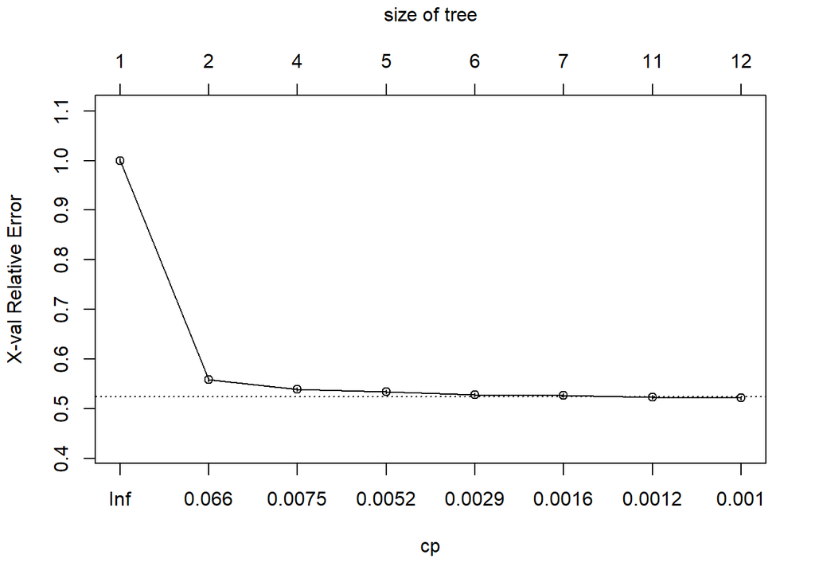

```r
plotcp(fit.allp)
```

```r
summary(fit.allp)
```

```
Call:
rpart(formula = cardio ~ ., data = data.train, method = "class",
    control = rpart.control(minsplit = 1, cp = 0.001))
  n= 62313

           CP nsplit rel error    xerror        xstd
1 0.441832721      0 1.0000000 1.0000000 0.004024362
2 0.009818147      1 0.5581673 0.5582318 0.003605332
3 0.005739344      3 0.5385310 0.5385955 0.003565237
4 0.004643064      4 0.5327916 0.5343716 0.003556326
5 0.001837880      5 0.5281486 0.5282131 0.003543148
6 0.001346166      6 0.5263107 0.5270201 0.003540570
7 0.001031792     10 0.5209260 0.5226672 0.003531092
8 0.001000000     11 0.5198942 0.5212162 0.003527907

Variable importance
       ap_hi        ap_lo  cholesterol age_in_years       weight         gluc
          48           27            9            8            5            2

Node number 1: 62313 observations,    complexity param=0.4418327
  predicted class=1  expected loss=0.4977132  P(node) =1
    class counts: 31014 31299
   probabilities: 0.498 0.502
  left son=2 (37001 obs) right son=3 (25312 obs)
  Primary splits:
      ap_hi        < 129.5   to the left,  improve=6401.7890, (0 missing)
      ap_lo        < 85.5    to the left,  improve=4277.8140, (0 missing)
      cholesterol  < 1.5     to the left,  improve=1480.7500, (0 missing)
      age_in_years < 54.5    to the left,  improve=1321.4520, (0 missing)
      weight       < 78.5    to the left,  improve= 814.8274, (0 missing)
  Surrogate splits:
      ap_lo        < 84.5    to the left,  agree=0.840, adj=0.605, (0 split)
      cholesterol  < 1.5     to the left,  agree=0.640, adj=0.114, (0 split)
      weight       < 82.5    to the left,  agree=0.637, adj=0.107, (0 split)
      age_in_years < 60.5    to the left,  agree=0.610, adj=0.041, (0 split)
      gluc         < 1.5     to the left,  agree=0.604, adj=0.025, (0 split)

Node number 2: 37001 observations,    complexity param=0.009818147
  predicted class=0  expected loss=0.3148293  P(node) =0.5937926
    class counts: 25352 11649
```

[output cut: 194 more lines]

```

Node number 37: 114 observations
  predicted class=1  expected loss=0.3596491  P(node) =0.001829474
    class counts:    41    73
   probabilities: 0.360 0.640

Node number 48: 2851 observations
  predicted class=0  expected loss=0.470712  P(node) =0.04575289
    class counts:  1509  1342
   probabilities: 0.529 0.471

Node number 49: 1995 observations
  predicted class=1  expected loss=0.4010025  P(node) =0.03201579
    class counts:   800  1195
   probabilities: 0.401 0.599
```

```r
print(fit.allp)
```

```
n= 62313

node), split, n, loss, yval, (yprob)
      * denotes terminal node

 1) root 62313 31014 1 (0.4977132 0.5022868)
   2) ap_hi< 129.5 37001 11649 0 (0.6851707 0.3148293)
     4) age_in_years< 54.5 22934  5362 0 (0.7661987 0.2338013)
       8) cholesterol< 2.5 21936  4791 0 (0.7815919 0.2184081) *
       9) cholesterol>=2.5 998   427 1 (0.4278557 0.5721443)
        18) gluc>=2.5 575   259 0 (0.5495652 0.4504348)
          36) weight< 80.5 461   186 0 (0.5965293 0.4034707) *
          37) weight>=80.5 114    41 1 (0.3596491 0.6403509) *
        19) gluc< 2.5 423   111 1 (0.2624113 0.7375887) *
     5) age_in_years>=54.5 14067  6287 0 (0.5530675 0.4469325)
      10) cholesterol< 2.5 12594  5246 0 (0.5834524 0.4165476)
        20) age_in_years< 60.5 9266  3493 0 (0.6230304 0.3769696) *
        21) age_in_years>=60.5 3328  1575 1 (0.4732572 0.5267428) *
      11) cholesterol>=2.5 1473   432 1 (0.2932790 0.7067210) *
   3) ap_hi>=129.5 25312  5662 1 (0.2236884 0.7763116)
     6) ap_hi< 138.5 8305  3319 1 (0.3996388 0.6003612)
      12) cholesterol< 2.5 6763  3012 1 (0.4453645 0.5546355)
        24) age_in_years< 58.5 4846  2309 1 (0.4764754 0.5235246)
          48) ap_lo< 89.5 2851  1342 0 (0.5292880 0.4707120) *
          49) ap_lo>=89.5 1995   800 1 (0.4010025 0.5989975) *
        25) age_in_years>=58.5 1917   703 1 (0.3667188 0.6332812) *
      13) cholesterol>=2.5 1542   307 1 (0.1990921 0.8009079) *
     7) ap_hi>=138.5 17007  2343 1 (0.1377668 0.8622332) *
```

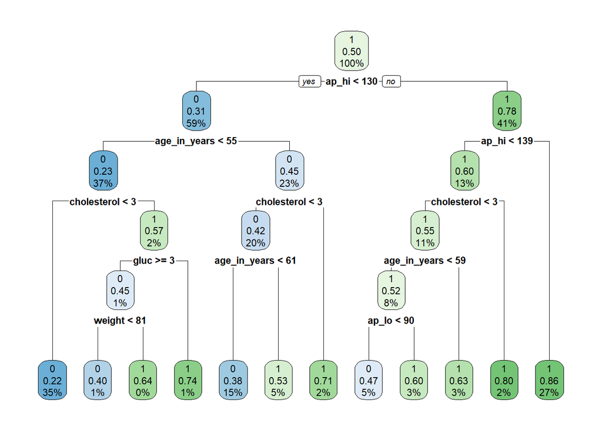

```r
library(rpart.plot)
rpart.plot(fit.allp, extra="auto")
```

```r
#Cross-Validation Data Confustion Matrix
cross_df<-data.frame(actual=data.cross$cardio, pred=NA)
cross_df$pred<-predict(fit.allp, newdata=data.cross, type="class")
(conf_matrix_base_cross<-table(cross_df$actual, cross_df$pred))
```

```
       0    1
  0 2450  633
  1 1008 2141
```

In the confusion matrix of Cross-Validation data for Binary Tree Model, there are 2450 true positive, 2141 true negative, 633 false positive and 1008 false negative.

```r
library(caret)
sensitivity(conf_matrix_base_cross)
```

```
[1] 0.708502
```

```r
specificity(conf_matrix_base_cross)
```

```
[1] 0.7718097
```

```r
(mis.rate<-conf_matrix_base_cross[1,2]+conf_matrix_base_cross[2,1])/sum(conf_matrix_base_cross)
```

```
[1] 0.2633184
```

```r
(accuracy <- sum(diag(conf_matrix_base_cross)) / sum(conf_matrix_base_cross))
```

```
[1] 0.7366816
```

The sensitivity, specificity, misclassification rate and accuracy are 70.85%, 77.18%, 26.33% and 73.66% respectively.

```r
#Test Data Confustion Matrix
test_df<-data.frame(actual=data.test$cardio, pred=NA)
test_df$pred<-predict(fit.allp, newdata=data.test, type="class")
(conf_matrix_base_test<-table(test_df$actual, test_df$pred))
```

```
       0    1
  0 2731  716
  1 1153 2325
```

In the confusion matrix of testing data for Binary Tree Model, there are 2731 true positive, 2325 true negative, 716 false positive and 1153 false negative.

```r
#Test Data
library(caret)
sensitivity(conf_matrix_base_test)
```

```
[1] 0.7031411
```

```r
specificity(conf_matrix_base_test)
```

```
[1] 0.7645511
```

```r
(mis.rate<-conf_matrix_base_test[1,2]+conf_matrix_base_test[2,1])/sum(conf_matrix_base_test)
```

```
[1] 0.2698917
```

```r
(accuracy <- sum(diag(conf_matrix_base_test)) / sum(conf_matrix_base_test))
```

```
[1] 0.7301083
```

The sensitivity, specificity, misclassification rate and accuracy are 70.31%, 76.46%, 26.98% and 73.01% respectively.

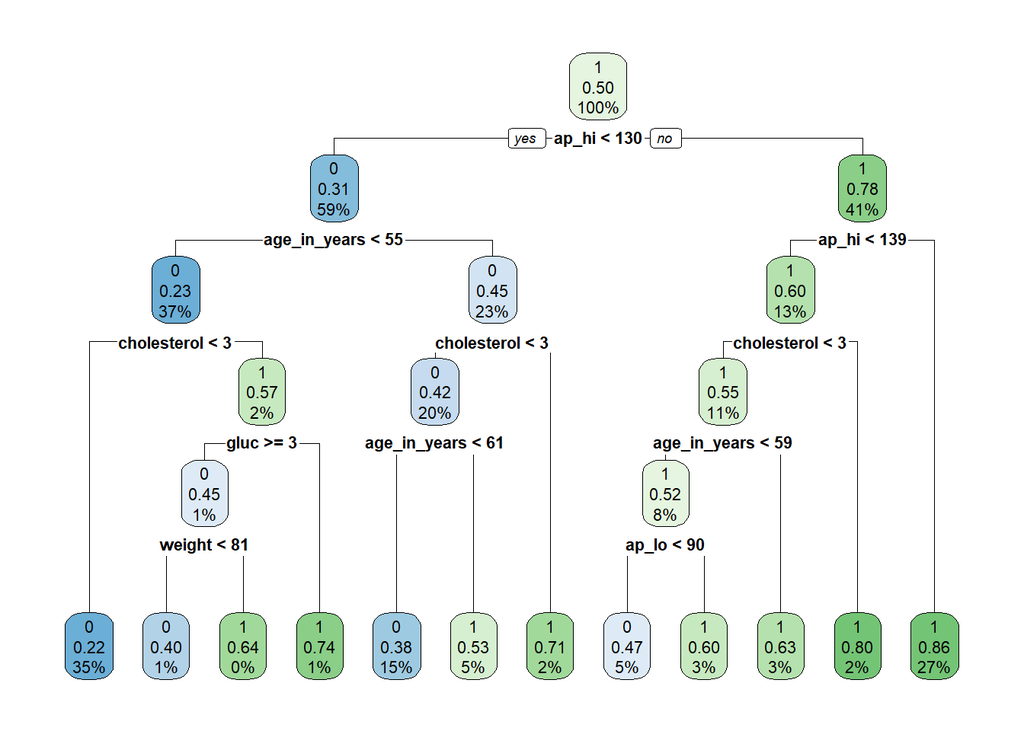

```r
pfit.allp <- prune(fit.allp, cp =
fit.allp$cptable[which.min(fit.allp$cptable[, "xerror"]), "CP"])
rpart.plot(pfit.allp, extra="auto")
```

Same with the full.allp

#Random Forest

```r
library(ranger)
fit.rf<-ranger(cardio~., data=train.set, importance = 'impurity', mtry = 3)
print(fit.rf)
```

```
Ranger result

Call:
 ranger(cardio ~ ., data = train.set, importance = "impurity",      mtry = 3)

Type:                             Classification
Number of trees:                  500
Sample size:                      56081
Number of independent variables:  11
Mtry:                             3
Target node size:                 1
Variable importance mode:         impurity
Splitrule:                        gini
OOB prediction error:             26.06 %
```

For the random forest model, the model is used for classification tasks and the total number of trees in the random forest, there are 500 trees were grown. In the training set, we have 56081 numbers of sample used and 11 predictor variables used in the model.The number of predictor variables randomly sampled at each split when growing a tree is 3. The split rule indicates that the Gini impurity us used as the criterion for selecting the best split at each node. The Out-of-Bag (OOB) Prediction Error is 26.06%, that represents the estimated classification error using out-of-bag samples.

Overall, the result suggests that a random forest model with 500 trees an a subset of 3 randomly selected variables at each split was trained on the provided dataset for a classification task, and the estimated out-of-bag error is around 26.06%.

```r
library(vip)
(v1<-vi(fit.rf))
```

```
# A tibble: 11 × 2
   Variable     Importance
   <chr>             <dbl>
 1 ap_hi             5042.
 2 weight            3040.
 3 age_in_years      2899.
 4 height            2680.
 5 ap_lo             2476.
 6 cholesterol       1057.
 7 gluc               430.
 8 female             356.
 9 active             315.
10 smoke              215.
11 alco               185.
```

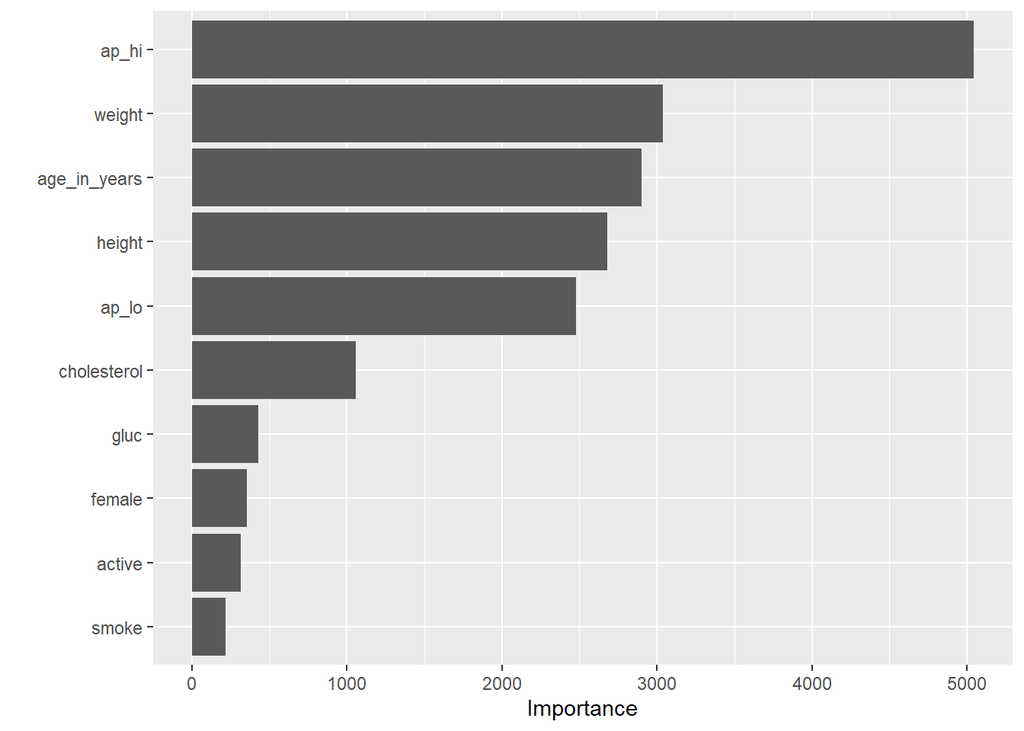

```r
vip(v1)
```

The variable importance output ranks predictor variables based on their contribution to the model’s predictive power, measured by Gini impurity.

From the result an graph above, ‘ap_hi’ has the highest importance, indicating a significant impact. ‘weight’ follows as the second most important predictor. ‘age_in_years’ and ‘height’ are also influential, ranking third and fourth, respectively. ‘ap_lo’, ‘chlesterol’, and ‘gluc’ contribute moderately. ‘female’(gender), ‘acctive, and ’smoke’ are less influential.

```r
#Cross-Validation Data Prediction for Random Forest
pred_cross<-predict(fit.rf, data=cross.set)
cross_df<-data.frame(actual=cross.set$cardio, pred=NA)
cross_df$pred<-pred_cross$predictions
(conf_matrix_rf_cross<-table(cross_df$pred, cross_df$actual))
```

```
       0    1
  0 2387  945
  1  696 2204
```

```r
library(caret)
sensitivity(conf_matrix_rf_cross)
```

```
[1] 0.7742459
```

```r
specificity(conf_matrix_rf_cross)
```

```
[1] 0.6999047
```

```r
(conf_matrix_rf_cross[1,2] +conf_matrix_rf_cross[2,1])/sum(conf_matrix_rf_cross)
```

```
[1] 0.2633184
```

```r
(accuracy <- sum(diag(conf_matrix_rf_cross)) / sum(conf_matrix_rf_cross))
```

```
[1] 0.7366816
```

The sensitivity, specificity, misclassification rate and accuracy are 77.42%, 69.99%, 26.33% and 73.66% respectively.

```r
#Test Data Prediction for Random Forest
pred_test<-predict(fit.rf, data=test.set)
pred_test_AUC<-predict(fit.rf, data=test.set)$predictions
test_df<-data.frame(actual=test.set$cardio, pred=NA)
test_df$pred<-pred_test$predictions
(conf_matrix_rf_test<-table(test_df$pred, test_df$actual))
```

```
       0    1
  0 2708 1073
  1  739 2405
```

```r
library(caret)
sensitivity(conf_matrix_rf_test)
```

```
[1] 0.7856107
```

```r
specificity(conf_matrix_rf_test)
```

```
[1] 0.6914894
```

```r
(conf_matrix_rf_test[1,2] +conf_matrix_rf_test[2,1])/sum(conf_matrix_rf_test)
```

```
[1] 0.2616606
```

```r
(accuracy <- sum(diag(conf_matrix_rf_test)) / sum(conf_matrix_rf_test))
```

```
[1] 0.7383394
```

The sensitivity, specificity, misclassification rate and accuracy are 78.56%, 69.14%, 26.17% and 73.83% respectively.

```r
library(ranger)
fit.rf_drop1<-ranger(cardio~height+weight +ap_hi+ap_lo+ cholesterol+age_in_years, data=train.set, importance = 'impurity', mtry = 3)
print(fit.rf_drop1)
```

```
Ranger result

Call:
 ranger(cardio ~ height + weight + ap_hi + ap_lo + cholesterol +      age_in_years, data = train.set, importance = "impurity",      mtry = 3)

Type:                             Classification
Number of trees:                  500
Sample size:                      56081
Number of independent variables:  6
Mtry:                             3
Target node size:                 1
Variable importance mode:         impurity
Splitrule:                        gini
OOB prediction error:             28.17 %
```

```r
library(ranger)
fit.rf_drop2<-ranger(cardio~height+weight +ap_hi+ap_lo+ cholesterol+age_in_years+gluc+female, data=train.set, importance = 'impurity', mtry = 3)
print(fit.rf_drop2)
```

```
Ranger result

Call:
 ranger(cardio ~ height + weight + ap_hi + ap_lo + cholesterol +      age_in_years + gluc + female, data = train.set, importance = "impurity",      mtry = 3)

Type:                             Classification
Number of trees:                  500
Sample size:                      56081
Number of independent variables:  8
Mtry:                             3
Target node size:                 1
Variable importance mode:         impurity
Splitrule:                        gini
OOB prediction error:             26.78 %
```

#Gradient Boosting

```r
library(xgboost)
library(Matrix)
matrix_predictors.train <-as.matrix(sparse.model.matrix(cardio ~., data = train.set))[, -1]
matrix_predictors.test <-as.matrix(sparse.model.matrix(cardio ~., data = test.set))[, -1]
matrix_predictors.cross <-as.matrix(sparse.model.matrix(cardio ~., data = cross.set))[, -1]
```

We have load the R package ‘xgboost’ for gradient boosting and ‘Matrix’ for handling sparse matrices. We have prepared sparse matrixes for the prediction variables in the training, test, and cross-validation sets.

```r
# Train dataset
pred.train.gbm <- data.matrix(matrix_predictors.train) # predictors only
#convert factor to numeric
train.set.gbm <- as.numeric(as.character(train.set$cardio))
dtrain <- xgb.DMatrix(data = pred.train.gbm, label = train.set.gbm)


# Test dataset
pred.test.gbm <- data.matrix(matrix_predictors.test) # predictors only
#convert factor to numeric
test.set.gbm <- as.numeric(as.character(test.set$cardio))
dtest <- xgb.DMatrix(data = pred.test.gbm, label = test.set.gbm)

# Cross-Validation dataset
pred.cross.gbm <- data.matrix(matrix_predictors.cross) # predictors only
#convert factor to numeric
cross.set.gbm <- as.numeric(as.character(cross.set$cardio))
dcross <- xgb.DMatrix(data = pred.cross.gbm, label = cross.set.gbm)
```

We converted the predictor variables and target variable from three datasets into formats suitable for training and evaluating an XGBoost model.

```r
watchlist <- list(train = dtrain, test = dtest, cross = dcross)
param <- list(max_depth = 2, eta = 1, nthread = 2,
objective = "binary:logistic", eval_metric = "auc")
```

The watchlist is to monitor the performance of the model on both the training and test sets during the training process. It helps to assess whether the model is learning and generalizing well.

‘param’ is used to control how the XGBoost model is trained and how it behaves during the training process.

```r
model.xgb <- xgb.train(param, dtrain, nrounds = 2, watchlist)
```

```r
pred.y.train <- predict(model.xgb, pred.train.gbm)
prediction.train <- as.numeric(pred.y.train > 0.5)
# Measure prediction accuracy on train data
(tab_train<-table(train.set.gbm, prediction.train))
```

```
             prediction.train
train.set.gbm     0     1
            0 22057  5874
            1  9010 19140
```

In the confusion matrix of training data for Gradient Boosting Model, there are 22057 true positive, 19140 true negative, 5874 false positive and 9010 false negative.

```r
library(caret)
sensitivity(tab_train)
```

```
[1] 0.7099817
```

```r
specificity(tab_train)
```

```
[1] 0.7651715
```

```r
sum(diag(tab_train))/sum(tab_train)
```

```
[1] 0.7345982
```

The sensitivity, specificity and accuracy are 71%, 76.52%,and 73.46% respectively.

```r
#Prediction for Cross-Validation Data
pred.y_cross = predict(model.xgb, pred.cross.gbm)
prediction_cross <- as.numeric(pred.y_cross > 0.5)
print(head(prediction_cross))
```

```
[1] 1 0 0 1 0 0
```

```r
#Cross-Validation Data for Gradient Boosting
 (tab1_cross<-table(cross.set.gbm,prediction_cross))
```

```
             prediction_cross
cross.set.gbm    0    1
            0 2436  647
            1 1027 2122
```

In the confusion matrix of cross-validation data for Gradient Boosting Model, there are 2436 true positive, 2122 true negative, 647 false positive and 1027 false negative.

```r
library(caret)
sensitivity(tab1_cross)
```

```
[1] 0.7034363
```

```r
specificity(tab1_cross)
```

```
[1] 0.7663416
```

```r
#accuracy
sum(diag(tab1_cross))/sum(tab1_cross)
```

```
[1] 0.7313864
```

The sensitivity, specificity and accuracy for cross-validation data are 70.34%, 76.63%,and 73.13% respectively.

```r
#AUC and ROC for Cross-Validation Data
roc_xgb<- roc(cross.set$cardio, pred.y_cross)
auc_xgb <- auc(roc_xgb)
cat("AUC for Gradient Boosting:", auc_xgb, "\n")
```

```
AUC for Gradient Boosting: 0.7941718
```

```r
#Prediction for Test Data
pred.y = predict(model.xgb, pred.test.gbm)
prediction_test <- as.numeric(pred.y > 0.5)
print(head(prediction_test))
```

```
[1] 1 1 1 1 1 1
```

```r
#Test Data for Gradient Boosting
 (tab1_test<-table(test.set.gbm,prediction_test))
```

```
            prediction_test
test.set.gbm    0    1
           0 2714  733
           1 1153 2325
```

In the confusion matrix of testing data for Gradient Boosting Model, there are 2714 true positive, 2325 true negative, 733 false positive and 1153 false negative.

```r
library(caret)
sensitivity(tab1_test)
```

```
[1] 0.701836
```

```r
specificity(tab1_test)
```

```
[1] 0.7603009
```

```r
#accuracy
sum(diag(tab1_test))/sum(tab1_test)
```

```
[1] 0.7276534
```

The sensitivity, specificity and accuracy for test data are 70.18%, 76.03%,and 72.77% respectively.

```r
#AUC and ROC for Testing Data
roc_xgb<- roc(test.set$cardio, pred.y)
auc_xgb <- auc(roc_xgb)
cat("AUC for Gradient Boosting:", auc_xgb, "\n")
```

```
AUC for Gradient Boosting: 0.7877445
```

**Key Highlights**

**The logistic regression model showed that age, weight, systolic blood pressure (ap_hi), diastolic blood pressure (ap_lo), cholesterol, glucose, smoking status, alcohol intake, and physical activity were statistically significant predictors of cardiovascular disease risk.** The model had an AUC of 0.80 on the test data.

**The CART decision tree made splits on ap_hi, age, and cholesterol levels.** The tree model had a sensitivity of 70.3%, specificity of 76.5%, misclassification rate of 27.0%, and accuracy of 73.0% on the test data.

**The random forest model showed ap_hi, weight, age, height, ap_lo, and cholesterol as the most important predictors.** This model achieved better performance than the single decision tree with a sensitivity of 78.6%, specificity of 69.1%, misclassification rate of 26.2%, and accuracy of 73.8% on the test data.

**Conclusion**

This research project aims to predict the likelihood of cardiovascular disease using different models. The study utilizes a dataset from Kaggle, containing information on 70,000 patients including various clinical characteristics such as age, blood pressure cholesterol and lifestyle choice.

The research employs several statistical methods, including logistic regression, binary tree modeling, random forest and gradient boosting. Logistic regression is used to model the probability of cardiovascular disease based on various features. Binary tree modeling involves recursive partitioning of the dataset based on predictor variables. Random forest, an ensemble learning method, build multiple decision trees to improve accuracy. Gradient boosting sequentially builds a series a weak learners to correct errors from previous models.

Outliers in the dataset are identified and removed, and the data is standardized. The logistic regression model indicates significant predictors such as age, weight, blood pressure, cholesterol, and lifestyle factors. The binary tree model splits the data based on conditions like blood pressure and age. Random forest identifies important predictors, with features like blood pressure and weight having high importance.

The study assesses model performance using confusion matrices, sensitivity, specificity, and accuracy metrics. For logistic regression, the model achieves an accuracy of approximately 73% on both cross-validation and test data. The binary tree model shows an accuracy of 73.66% on cross-validation and 73.01% on test data. Random forest achieves an accuracy of 73.66% on cross-validation and 73.83% on test data. Gradient boosting achieves an accuracy of 73.46% on training, 73.13% on cross-validation, and 72.77% on test data.

In conclusion, we were able to successfully develop models to predict cardiovascular disease risk using patient clinical data. The random forest model achieved the best predictive performance overall.

Some potential areas for future work include:

- Trying other machine learning algorithms such as neural networks or SVM
- Performing more extensive hyperparameter tuning
- Incorporating additional data sources or biomarkers
- Developing a user-friendly interface for individual risk calculation

The analyses overall provide insights into the key clinical factors that influence cardiovascular risk and can serve as the basis for developing risk assessment tools for preventative care. The machine learning models demonstrate promising accuracy and discrimination ability using this dataset. Additional external validation on other datasets would be needed before clinical application.